# Umweltdatenanalyse: airquality & CO2

Janka Schultze

2025-07-15

**Beschreibung:**  
Hier werden zwei Umweltdatensätze aus dem R-Standardumfang analysiert:  
- `airquality`: Luftqualitätsdaten aus New York (Mai–September 1973), inklusive Ozon-, Wind- und Temperaturmessungen.  
- `CO2`: Experimentelle Daten zur CO2-Aufnahme zweier Pflanzenarten unter verschiedenen Behandlungsbedingungen.

**Ziel:**  
Explorative Analyse der Zusammenhänge zwischen Umweltvariablen, Identifikation von Mustern und Einflussfaktoren auf Luftqualität und CO2-Aufnahme.

## Luftqualitätsanalyse `airquality`

#### Bibliotheken

```r
library(tidyverse)
```

#### Überblick über den Datensatz

```r
head(airquality)
```

|  | Ozone | Solar.R | Wind | Temp | Month | Day |
| --- | --- | --- | --- | --- | --- | --- |
| 1 | 41 | 190 | 7.4 | 67 | 5 | 1 |
| 2 | 36 | 118 | 8.0 | 72 | 5 | 2 |
| 3 | 12 | 149 | 12.6 | 74 | 5 | 3 |
| 4 | 18 | 313 | 11.5 | 62 | 5 | 4 |
| 5 | NA | NA | 14.3 | 56 | 5 | 5 |
| 6 | 28 | NA | 14.9 | 66 | 5 | 6 |

```r
str(airquality)
```

```
## 'data.frame':    153 obs. of  6 variables:
##  $ Ozone  : int  41 36 12 18 NA 28 23 19 8 NA ...
##  $ Solar.R: int  190 118 149 313 NA NA 299 99 19 194 ...
##  $ Wind   : num  7.4 8 12.6 11.5 14.3 14.9 8.6 13.8 20.1 8.6 ...
##  $ Temp   : int  67 72 74 62 56 66 65 59 61 69 ...
##  $ Month  : int  5 5 5 5 5 5 5 5 5 5 ...
##  $ Day    : int  1 2 3 4 5 6 7 8 9 10 ...
```

```r
summary(airquality)
```

```
##      Ozone           Solar.R           Wind             Temp
##  Min.   :  1.00   Min.   :  7.0   Min.   : 1.700   Min.   :56.00
##  1st Qu.: 18.00   1st Qu.:115.8   1st Qu.: 7.400   1st Qu.:72.00
##  Median : 31.50   Median :205.0   Median : 9.700   Median :79.00
##  Mean   : 42.13   Mean   :185.9   Mean   : 9.958   Mean   :77.88
##  3rd Qu.: 63.25   3rd Qu.:258.8   3rd Qu.:11.500   3rd Qu.:85.00
##  Max.   :168.00   Max.   :334.0   Max.   :20.700   Max.   :97.00
##  NA's   :37       NA's   :7
##      Month            Day
##  Min.   :5.000   Min.   : 1.0
##  1st Qu.:6.000   1st Qu.: 8.0
##  Median :7.000   Median :16.0
##  Mean   :6.993   Mean   :15.8
##  3rd Qu.:8.000   3rd Qu.:23.0
##  Max.   :9.000   Max.   :31.0
##
```

#### Visualisierungen

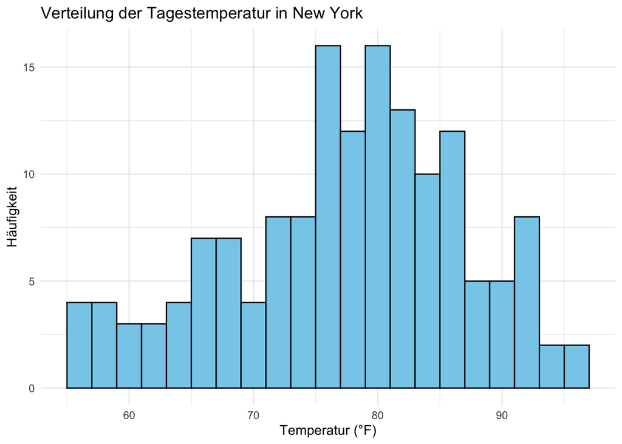

```r
# Verteilungen und Zusammenhänge
# Histogramm der Tagestemperatur

ggplot(airquality, aes(x = Temp)) +
geom_histogram(binwidth = 2, color = 'black', fill = 'skyblue') +
labs(
title = 'Verteilung der Tagestemperatur in New York',
x = 'Temperatur (°F)',
y = 'Häufigkeit'
) +
theme_minimal()
```

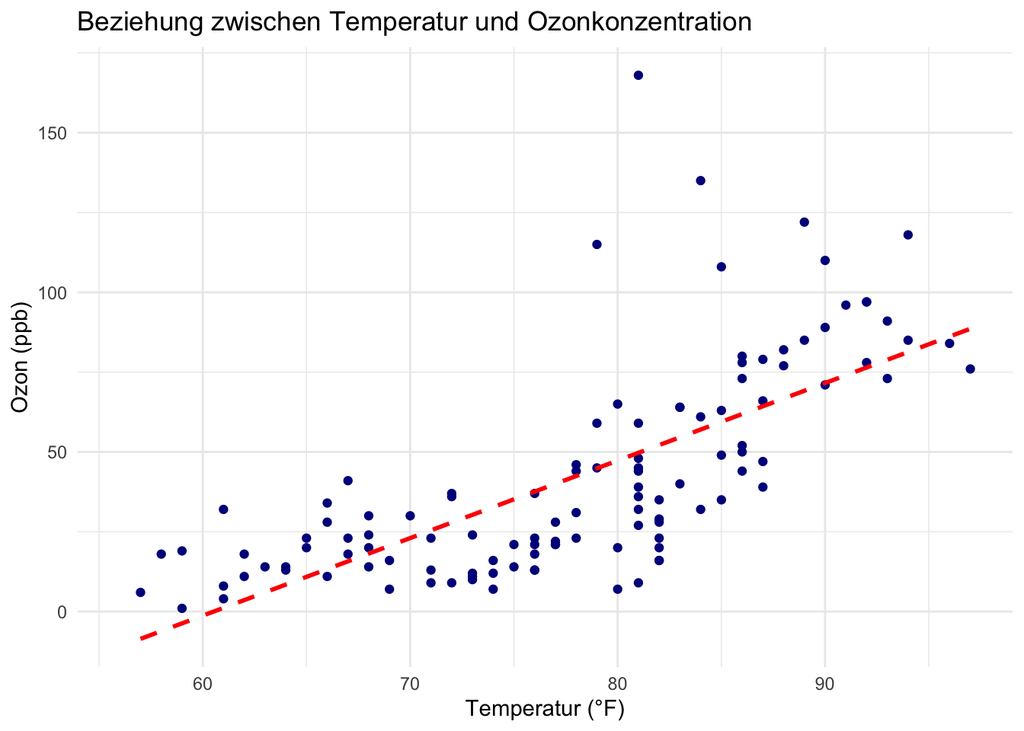

```r
# Scatterplot: Temperatur vs. Ozon

ggplot(airquality, aes(x = Temp, y = Ozone)) +
geom_point(color = "darkblue") +
geom_smooth(method = 'lm', se = FALSE, color = "red", linetype = "dashed") +
labs(
title = 'Beziehung zwischen Temperatur und Ozonkonzentration',
x = 'Temperatur (°F)',
y = 'Ozon (ppb)'
) +
theme_minimal()
```

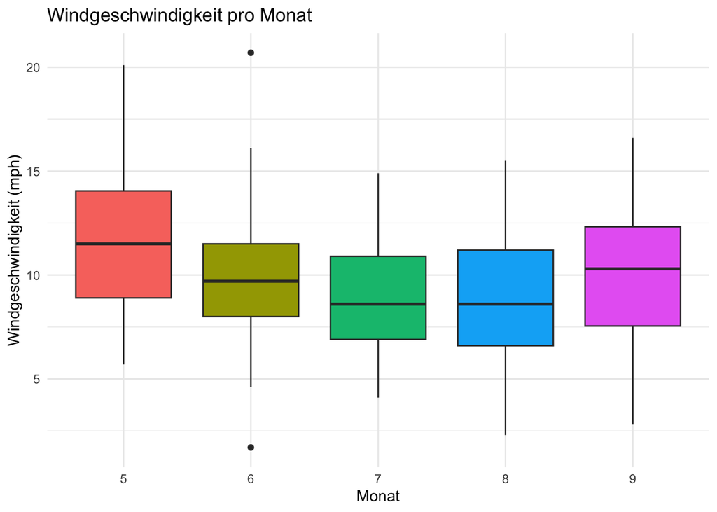

```r
# Boxplot: Windgeschwindigkeit pro Monat

ggplot(airquality, aes(x = as.factor(Month), y = Wind, fill = as.factor(Month))) +
geom_boxplot() +
labs(
title = 'Windgeschwindigkeit pro Monat',
x = 'Monat',
y = 'Windgeschwindigkeit (mph)'
) +
guides(fill = 'none') +
theme_minimal()
```

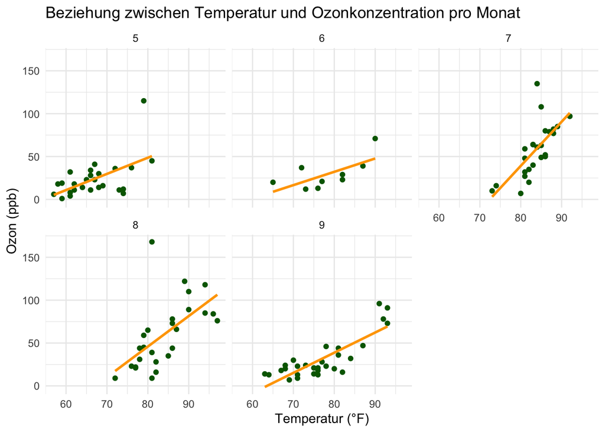

```r
# Scatterplot: Temperatur vs. Ozon (nach Monat)
# Schreiben
airquality_clean <- airquality %>% filter(!is.na(Ozone))

ggplot(airquality_clean, aes(x = Temp, y = Ozone)) +
geom_point(color = "darkgreen") +
geom_smooth(method = 'lm', se = FALSE, color = "orange") +
facet_wrap(~ Month) +
labs(
title = 'Beziehung zwischen Temperatur und Ozonkonzentration pro Monat',
x = 'Temperatur (°F)',
y = 'Ozon (ppb)'
) +
theme_minimal()
```

## Analyse der Pflanzenphysiologie `CO2`

#### Überblick über den Datensatz

```r
head(CO2)
```

|  | Plant | Type | Treatment | conc | uptake |
| --- | --- | --- | --- | --- | --- |
| 1 | Qn1 | Quebec | nonchilled | 95 | 16.0 |
| 2 | Qn1 | Quebec | nonchilled | 175 | 30.4 |
| 3 | Qn1 | Quebec | nonchilled | 250 | 34.8 |
| 4 | Qn1 | Quebec | nonchilled | 350 | 37.2 |
| 5 | Qn1 | Quebec | nonchilled | 500 | 35.3 |
| 6 | Qn1 | Quebec | nonchilled | 675 | 39.2 |

```r
str(CO2)
```

```
## Classes 'nfnGroupedData', 'nfGroupedData', 'groupedData' and 'data.frame':   84 obs. of  5 variables:
##  $ Plant    : Ord.factor w/ 12 levels "Qn1"<"Qn2"<"Qn3"<..: 1 1 1 1 1 1 1 2 2 2 ...
##  $ Type     : Factor w/ 2 levels "Quebec","Mississippi": 1 1 1 1 1 1 1 1 1 1 ...
##  $ Treatment: Factor w/ 2 levels "nonchilled","chilled": 1 1 1 1 1 1 1 1 1 1 ...
##  $ conc     : num  95 175 250 350 500 675 1000 95 175 250 ...
##  $ uptake   : num  16 30.4 34.8 37.2 35.3 39.2 39.7 13.6 27.3 37.1 ...
##  - attr(*, "formula")=Class 'formula'  language uptake ~ conc | Plant
##   .. ..- attr(*, ".Environment")=<environment: R_EmptyEnv>
##  - attr(*, "outer")=Class 'formula'  language ~Treatment * Type
##   .. ..- attr(*, ".Environment")=<environment: R_EmptyEnv>
##  - attr(*, "labels")=List of 2
##   ..$ x: chr "Ambient carbon dioxide concentration"
##   ..$ y: chr "CO2 uptake rate"
##  - attr(*, "units")=List of 2
##   ..$ x: chr "(uL/L)"
##   ..$ y: chr "(umol/m^2 s)"
```

```r
summary(CO2)
```

```
##      Plant             Type         Treatment       conc          uptake
##  Qn1    : 7   Quebec     :42   nonchilled:42   Min.   :  95   Min.   : 7.70
##  Qn2    : 7   Mississippi:42   chilled   :42   1st Qu.: 175   1st Qu.:17.90
##  Qn3    : 7                                    Median : 350   Median :28.30
##  Qc1    : 7                                    Mean   : 435   Mean   :27.21
##  Qc3    : 7                                    3rd Qu.: 675   3rd Qu.:37.12
##  Qc2    : 7                                    Max.   :1000   Max.   :45.50
##  (Other):42
```

#### Visualiserungen

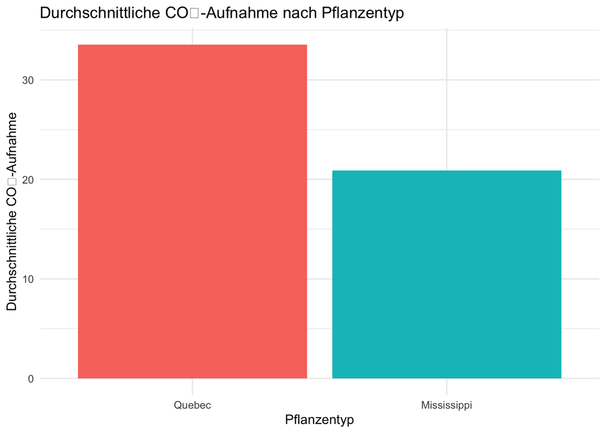

```r
# Durchschnittliche CO₂-Aufnahme nach Pflanzentyp

mean_uptake_type <- CO2 %>%
group_by(Type) %>%
summarise(Mean_Uptake = mean(uptake))

ggplot(mean_uptake_type, aes(x = Type, y = Mean_Uptake, fill = Type)) +
geom_col() +
labs(
title = 'Durchschnittliche CO₂-Aufnahme nach Pflanzentyp',
x = 'Pflanzentyp',
y = 'Durchschnittliche CO₂-Aufnahme'
) +
theme_minimal() +
theme(legend.position = "none")
```

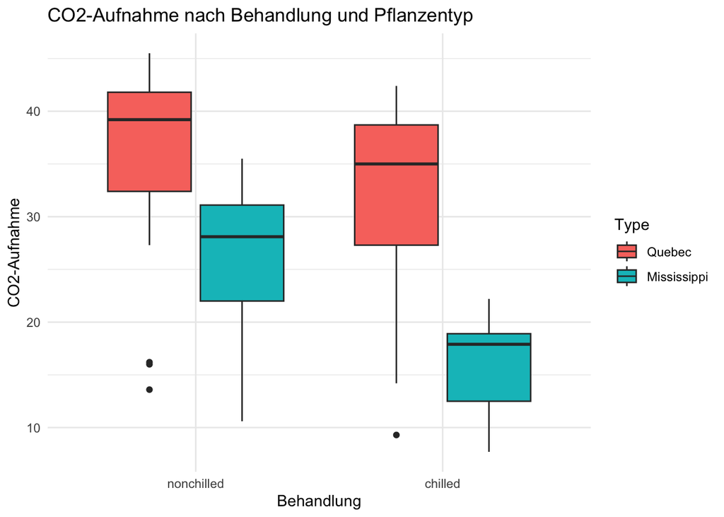

```r
# Einfluss von Behandlung und Pflanzentyp

ggplot(CO2, aes(x = Treatment, y = uptake, fill = Type)) +
geom_boxplot() +
labs(
title = 'CO2-Aufnahme nach Behandlung und Pflanzentyp',
x = 'Behandlung',
y = 'CO2-Aufnahme'
) +
theme_minimal()
```

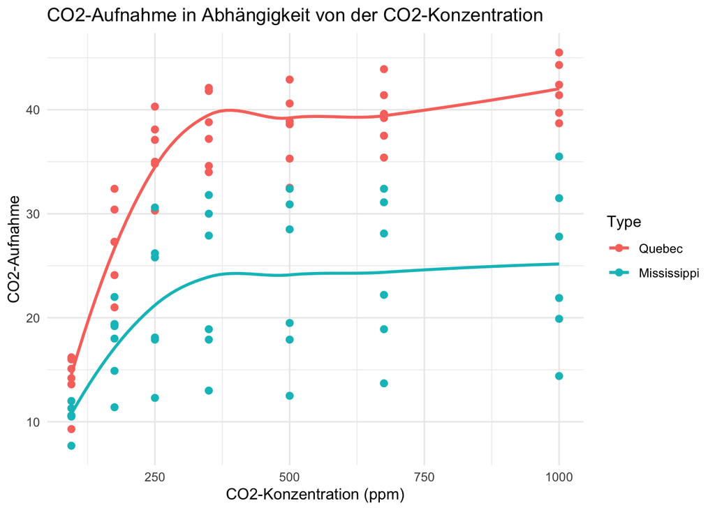

```r
# CO2-Aufnahme im Verhältnis zur CO2-Konzentration

ggplot(CO2, aes(x = conc, y = uptake, color = Type)) +
geom_point(size = 2) +
geom_smooth(method = "loess", se = FALSE) +
labs(
title = 'CO2-Aufnahme in Abhängigkeit von der CO2-Konzentration',
x = 'CO2-Konzentration (ppm)',
y = 'CO2-Aufnahme'
) +
theme_minimal()
```

### Insights `CO2`

Behandlung: „Nonchilled“-Bedingungen (nicht gekühlt) fördern deutlich höhere CO₂-Aufnahme.

Konzentrationseffekt: Die CO₂-Aufnahme steigt mit zunehmender CO₂-Konzentration an, flacht jedoch ab – klassischer Sättigungseffekt in der Photosynthese.

Interaktionseffekt: Der Einfluss von CO₂-Konzentration ist abhängig vom Pflanzentyp – deutet auf unterschiedliche physiologische Anpassungen hin.

## Gesamtfazit:

Beide Datensätze zeigen typische Muster umweltbiologischer Zusammenhänge:  
In der Luftqualitätsanalyse (airquality) wirken Temperatur und Windbedingungen stark auf die Ozonwerte.  
In der Pflanzenphysiologie (CO2) bestimmen Umweltfaktoren und biologische Unterschiede maßgeblich die CO₂-Aufnahme.